# Module_1: Alzheimer's Data Set Analysis

## Team Members:

Layla Ragland, Tripp Hilderbrand

## Project Title:

Alzheimer's, Education, and Disease Length Analysis

## Project Goal:

This project seeks to determine whether or not there is a correlation between Amyloid Beta protein levels and disease duration (or the legnth of time between Alzheimer's symptom onset to death) through computational and statistical analysis of a provided data set. Moreover, we wanted to investigate if this disease duration had any connection to the education levels of these patients.

Key reaserch questions:

(1) Does a patient's prior education level relate to the age of onset of Alzheimer’s disease?

(2) Did the duration of the disease (amount of time passed from onset to death) correlate with the amount of amyloid plaque found in the brain?

## Disease Background:

### Prevalence & incidence

- Prevelance of around 7.2 million Incidence, from the National Institutes of Health, is recorded that "approximately 910,000 people age 65 or older developed Alzheimer's dementia in the U.S. in 2011, a number that would be expected to be even higher in 2025 if updated CHAP estimates were available."

  Sources: https://pmc.ncbi.nlm.nih.gov/articles/PMC12040760/

### Economic burden

- The economic burden of Alzheimer's disease is very significant, as diagnosed patients often require substantial accomidations, treatments, and often must live in assisted living and/or memory care facillities. According to Nature, the total cost of care for someone with Alzheimer's disease and related dimentia (ADRD) was upwards of $28,000 per year in 2016, with total costs for ADRD patients in teh United States being in the hundreds of billions (about $355 billion) when additional factors like forgone wages are accounted for. Majority of these costs are paid for by Medicare and Medicaid Services, with up to 67% of total costs (or 1 out of every 5 dollars of medicare funding) is spent on the treatment and care of people with Alzheimer's. This makes Alzheimer's care and treatment some of the most expensive in America, totaling more than treatments for cancer or heart disease in the last 5 years of life.

  Sources: https://www.nature.com/articles/s41514-024-00136-6

  https://portal-legacy.alzimpact.org/media/serve/id/5a31f4becc26f (pdf)

#### Risk factors

- Some risk factors that have been identified is cognitive slowing or lack of mental stimulation in later life, as well as poor diet and exercise. There are also links to the ApoE gene.

  Sources: https://pmc.ncbi.nlm.nih.gov/articles/PMC12040760/

### Societal determinants

- Certain lifestyle and background factors can influence an individual's likelihood to develop Alzhimer's disease later in life. Many of these factors include education level, access to healthcare, and phyiscal environment in one's community, as well as someone's demographics. Some studies have shown an association between lower levels of education and development of Alzheimer's and dementia, with cognitive decline among adults age 45 and older being twice as high for people without a high school diploma. Some scientists believe that education and knowledge levels can be stored or "banked" in early years of life, a phenomenon called "cognitive reserve". Additionally, many people across the United States do not have access to adequate healthcare, reducing chances of early diagnosis and ease of treatment. Social isolation or loneliness has also been found to increase risk of developing Alzheimer's disease and dementia. Finally, specific demographics can increase someone's risk, as Women have an approximately 17% higher risk for developing Alzheimer's than men. Additionally, African Americans and Native Hawaiians are at highest risk for developing Alzheimer's, while Japanese Americans and Fillipinos were at a lower risk. These factors ultimately demonstrate the significant roles that lifestyle, background, and geography can play when it comes to affecting someone's risk of developing Alzheimer's.

  Sources: https://alz-journals.onlinelibrary.wiley.com/doi/10.1002/alz.12528

  https://www.cdc.gov/alzheimers-dementia/php/sdoh/index.html

### Symptoms

- Alzheimer's symptoms include a range of things from memory loss, challenges with daily taks, lack of spatial processing, issues with time-keeping, mood changes and personaility changes. These symptoms can vary day to day, often creating a sense of "good and bad days". Alzheimer's tends to develop into motor issues, including gait issues, poor balance, and eventually inability to swallow.

  Sources: https://pmc.ncbi.nlm.nih.gov/articles/PMC12040760/

### Diagnosis

- Early symptoms of Alzheimer's disease include memory loss, trouble concentrating, poor judgement and decision making, social withdrawl, changes in mood or personality, trouble with language skills, and trouble with routine daily tasks. To diagnose Alzheimer's, healthcare providers perform a series of tests including mental status testing, neurophychological tests, labrotory tests for certain proteins (specifically p-tau217 and amyloid proteins), and brain imaging tests such as an MRI, CT, or PET scan. Neurophysiologists and neurologists are typically responsible for testing and evaluating patients for Alzheimer's diagnosis. Early diagnosis can help patients begin therapies, medications, and clinical trials much earlier, reducing or slowing the impact of the disease.

  Source: https://www.mayoclinic.org/diseases-conditions/alzheimers-disease/in-depth/alzheimers/art-20048075

### Standard of care treatments (& reimbursement)

- Alzheimer's unfornuately has no cure as of right now. Instead, most individuals are cared for by a family member, child, spouse or hired caregiver. Family member care may not invoke monetary expense, but is linked with increased anxiety and decreased life quality for the caregiver. Because Alzheimer's devolves over time, they often have an increase in care needs as the disease progresses. Many individuals will end up in specialized long term care programs. For patients with Medicare, this will be a very expensive out of pocket cost for their families, while Medicaid does cover long term care stays. Some insurances cover the cost of long term stays, and others do not. Similarly, in home care to assist with house chores, feeding, bathing and other supplimental help to the main caregiver is not covered by Medicare either, and largely variable as to if it is covered by insurances of Medicaid. As for medications, a variety exist to ease some Alzheimer's symptoms, and are largely covered by most major insurance providers, including Medicare and Medicaid.

  Sources: https://pmc.ncbi.nlm.nih.gov/articles/PMC12040760/

### Disease progression & prognosis

- Progression of Alzheimer’s disease happens in several stages. In the early stage, patients may function independently but may display some symptoms, including having issues with memory cognition. Middle stage is often the longest stage for most patients, and lasts several years. During this stage, symptoms of dementia are much more present, and patients require a higher level of care. Damage to nerve cells can make it difficult for patients to express thoughts and perform daily tasks independently. Symptoms of middle stage Alzheimer’s include being unable to recall important information such as their address or phone number, having trouble controlling their bladder and bowels, experiencing changes in sleep patterns, and demonstrating personality or behavioral changes. Many patients in this stage are still able to participate in daily activities, but require assistance. The final stage of Alzheimer's is the late stage, where patients have worsened symptoms and require around the clock care. Patients may have difficulty doing basic tasks, such as eating, walking, sitting, and swallowing. They may also become more venerable to infections.

  Source: https://www.alz.org/alzheimers-dementia/stages

### Continuum of care providers

- Care for patients with Alzheimer's tends to involve a general care provider, then often a geriatric specialist or maybe straigyht to the nuerologist. From diagnosis onwards, routine appointments may occur with a nuerologists, and the pateint will reciee most of their care from a home care provider, a pharmacists, or a care facility.

  Sources: https://pmc.ncbi.nlm.nih.gov/articles/PMC12040760/

### Biological mechanisms (anatomy, organ physiology, cell & molecular physiology)

- The main characteristic of Alzheimer’s disease includes the extracellular buildup of amyloid-beta plaques and tau protein tangles in the intracellular environment. The accumulation of these compounds in the brain can result in neuron death and loss of synapses, which can contribute to progressive cognitive decline. Additionally, newer research has demonstrated that Alzheimer’s disease has been shown to alter glutamate signaling, the primary neurotransmitter in the Central Nervous System. This results in chronic activation of NMDA receptors due to potential glutamate toxicity, which has been shown to lead to neurodegeneration. Many different parts of the brain are susceptible to this damage, including the brain stem, amygdala, hypothalamus, and regions of the cerebral cortex, and others. This directly results in a decline in the ability of the brain to function and causes common symptoms like memory loss and having trouble thinking, speaking, and completing actions.

  Sources: https://pmc.ncbi.nlm.nih.gov/articles/PMC5290713/

### Clinical Trials/next-gen therapies

- Alzheimer's research is at the forefront of many researcher's minds, and as such, many new avenues of treatment have arisen in recent years. To start, blood screening options are now being more widely avabile to check for Alzheimer's years or even decades before symptoms begin. Another possible therapy being considered is lithium remediation via dietary suppliments, as a decerease in lithium is shown to accelerate the disease progession, and is common in patients as amyloid plaque uses lithium stores. Another example is GRK2 proteins and Compound 10. GRK2 become inactive and harmful in Alzheimer's, and so some current experimenetal models are showing that by making Compound 10 bind to GRK2, it slows the nerve cell death and therefore increased life span. However, treatments like these require significant long term trials and FDA testing, and so the timeline to be avaible on the market is likely long.

  Sources: https://www.mayoclinic.org/diseases-conditions/alzheimers-disease/in-depth/new-blood-tests-alzheimers/art-20585060

  https://neurosciencenews.com/compound-10-alzheimers-30837/

  https://pmc.ncbi.nlm.nih.gov/articles/PMC12688778/

## Data-Set:

The data set used here originated from an Allen Institute and University of Washington study analyzing the postmortem brains of ~84 participants. The brains were processed using RNA sequencing for gene expression, as well as tissue slicing and data collecting. This brain tissue data included pH, RNA integrity numbers, as well as concentrations of amlyoid beta amounts, tau, and a couple other relevant proteins. The data set is not completely filled out, as some of the lower quality, or unrelaible measurements were left out entirely.

For the data used in this analysis, we will further explain the collection apparatuses. The amyloid plaque 40 and 42 was measured with immunohistochemistry, which involved cutting the tissues, labeling the amyloid beta with an monoclonal antibody, and then staining via a secondary polymer reaction with an enzyme. For the general life data (race, education level, etc), these were collected via surveys under informed consent that were part of the routine clinical visits.

Source: "Integrated multimodal cell atlas of Alzheimer’s disease", Nature Nueroscience, Volume 27, https://doi.org/10.1038/s41593-024-01774-5

## Data Analysis:

Our data analysis contains several key steps. Here will be an overview of each step, and then the steps will be demonstrated one by one.

Step 1: Create the necessary tools for analysis. For us, this was the creation of a Patient class from the csv file

Step 2: Data consideration. We observed the data and deemed an outlier test neccessary.

Step 3: We then began to compile the data into graphical analysis

Step 4: We ran statistical tests, including linear regression, and finding R squared and p values in order to record any statistical significance.

*Step 1: Imports and Patient Class*

```python
# Package installations
from patient import Patient

# these other functions will help with the math and plotting skills needed for graphs
import matplotlib.pyplot as plt
from scipy import stats
import numpy as np
import statistics
from sklearn.linear_model import LinearRegression
from pathlib import Path
import pandas as pd
```

Now, the data was processed in a file via a class definition in the file 'patient'. These can be found in the Github, but the class's code is not explicitly present in this explanation. Below, the data is turned into instances of the Patient class, so that it contains the needed attributes for the following analysis.

```python
Patient.instantiate_from_csv("Metadata and Protein Data for Module 1.csv")
Patient.all_patients = [p for p in Patient.all_patients if p.donor_id!= "H20.33.018"]  # This is the removal of our outlier, explained later
```

```python
# Starts unpacking data found in our dataset .csv file

# Check how many patients were created
print(f"Number of patients = {len(Patient.all_patients)}")

# Display patient data from Patient class
print("\nExamples of patients included in the dataset:")
for patient in Patient.all_patients:
    print(patient)
```

```
Number of patients = 83

Examples of patients included in the dataset:
H19.33.004: (Female | 80.0 | Bachelors | No dementia | ABeta42 = 0.971578947)
H20.33.001: (Male | 82.0 | Bachelors | No dementia | ABeta42 = 2.744210526)
H20.33.002: (Female | 97.0 | High School | No dementia | ABeta42 = 0.147157895)
H20.33.004: (Male | 86.0 | Trade School/ Tech School | Dementia | ABeta42 = 80.26631579)
H20.33.005: (Female | 99.0 | High School | No dementia | ABeta42 = 16.15684211)
H20.33.008: (Female | 92.0 | Graduate (PhD/Masters) | No dementia | ABeta42 = 101.8305263)
H20.33.011: (Female | 93.0 | Bachelors | Dementia | ABeta42 = 60.51157895)
H20.33.012: (Female | 91.0 | Graduate (PhD/Masters) | No dementia | ABeta42 = 47.70947368)
H20.33.013: (Male | 94.0 | Trade School/ Tech School | No dementia | ABeta42 = 24.78105263)
H20.33.014: (Female | 82.0 | Graduate (PhD/Masters) | No dementia | ABeta42 = 16.13789474)
H20.33.015: (Male | 88.0 | Graduate (PhD/Masters) | Dementia | ABeta42 = 27.60947368)
H20.33.016: (Female | 93.0 | Trade School/ Tech School | Dementia | ABeta42 = 21.27368421)
H20.33.017: (Male | 69.0 | Trade School/ Tech School | Dementia | ABeta42 = 209.4347368)
H20.33.019: (Female | 87.0 | Trade School/ Tech School | No dementia | ABeta42 = 28.81368421)
H20.33.020: (Male | 81.0 | High School | Dementia | ABeta42 = 45.72842105)
H20.33.024: (Male | 90.0 | Graduate (PhD/Masters) | No dementia | ABeta42 = 105.1042105)
H20.33.025: (Male | 94.0 | High School | No dementia | ABeta42 = 95.79263158)
H20.33.026: (Female | 75.0 | High School | Dementia | ABeta42 = 63.37473684)
H20.33.027: (Female | 99.0 | High School | No dementia | ABeta42 = 29.95578947)
H20.33.028: (Female | 94.0 | Trade School/ Tech School | Dementia | ABeta42 = 18.94736842)
H20.33.029: (Female | 91.0 | High School | Dementia | ABeta42 = 28.85473684)
H20.33.030: (Female | 86.0 | Bachelors | No dementia | ABeta42 = 58.26631579)
H20.33.031: (Female | 87.0 | High School | Dementia | ABeta42 = 42.51368421)
H20.33.032: (Male | 98.0 | Bachelors | No dementia | ABeta42 = 44.25684211)
H20.33.033: (Male | 68.0 | Graduate (PhD/Masters) | Dementia | ABeta42 = 123.3684211)
H20.33.034: (Female | 85.0 | Bachelors | No dementia | ABeta42 = 4.96)
H20.33.035: (Female | 99.0 | Bachelors | No dementia | ABeta42 = 0.525263158)
H20.33.036: (Female | 100.0 | Trade School/ Tech School | No dementia | ABeta42 = 102.4557895)
H20.33.037: (Female | 96.0 | Graduate (PhD/Masters) | Dementia | ABeta42 = 67.65473684)
H20.33.038: (Female | 90.0 | Graduate (PhD/Masters) | Dementia | ABeta42 = 81.13789474)
H20.33.039: (Female | 96.0 | Trade School/ Tech School | No dementia | ABeta42 = 27.33473684)
H20.33.040: (Male | 98.0 | Trade School/ Tech School | Dementia | ABeta42 = 12.69789474)
H20.33.041: (Female | 91.0 | Bachelors | Dementia | ABeta42 = 242.5863158)
H20.33.043: (Male | 85.0 | Graduate (PhD/Masters) | No dementia | ABeta42 = 60.95368421)
H20.33.044: (Male | 81.0 | Graduate (PhD/Masters) | No dementia | ABeta42 = 0.245263158)
H20.33.045: (Female | 77.0 | Graduate (PhD/Masters) | Dementia | ABeta42 = 142.778)
H20.33.046: (Male | 94.0 | Professional | Dementia | ABeta42 = 69.98842105)
```

[output cut: 31 more lines]

```
H21.33.033: (Female | 83.0 | Trade School/ Tech School | No dementia | ABeta42 = 31.76315789)
H21.33.034: (Female | 90.0 | Bachelors | Dementia | ABeta42 = 161.0947368)
H21.33.035: (Female | 97.0 | High School | No dementia | ABeta42 = 143.4642105)
H21.33.036: (Female | 93.0 | Trade School/ Tech School | No dementia | ABeta42 = 75.78947368)
H21.33.037: (Female | 88.0 | Graduate (PhD/Masters) | No dementia | ABeta42 = 0.449649126)
H21.33.038: (Female | 84.0 | High School | No dementia | ABeta42 = 0.122631579)
H21.33.039: (Female | 88.0 | High School | Dementia | ABeta42 = 76.22631579)
H21.33.040: (Male | 83.0 | Bachelors | No dementia | ABeta42 = 0.490526316)
H21.33.041: (Female | 98.0 | High School | No dementia | ABeta42 = 88.16947368)
H21.33.042: (Female | 91.0 | Trade School/ Tech School | Dementia | ABeta42 = 47.93263158)
H21.33.043: (Female | 95.0 | Bachelors | Dementia | ABeta42 = 29.89263158)
H21.33.044: (Female | 88.0 | Trade School/ Tech School | Dementia | ABeta42 = 33.63789474)
H21.33.045: (Female | 94.0 | High School | Dementia | ABeta42 = 53.87894737)
H21.33.046: (Male | 97.0 | Professional | Dementia | ABeta42 = 19.19578947)
H21.33.047: (Male | 90.0 | Professional | No dementia | ABeta42 = 0.049052632)
```

*Step 2: Outlier Analysis*

After our initial assessing of the data, we determined that an outlier analysis was necessary. We did a traditional Inter Quartile range check for values more than 1.5 times away from the range, and found 5 values here. Then, to further consider them, we ran a Z test to see how many standard deviations those data points were away from the mean. Z values of greater than 3 were eliminated. This meant that we removed 1 outlier.

```
Normal range: -95.74 to 177.49
      Donor ID  ABeta42 pg/ug         z
12  H20.33.017     209.434737  0.887514
13  H20.33.018    1412.566961  8.383236
33  H20.33.041     242.586316  1.094054
44  H21.33.007     287.412000  1.373326
62  H21.33.026     263.536842  1.224579
```

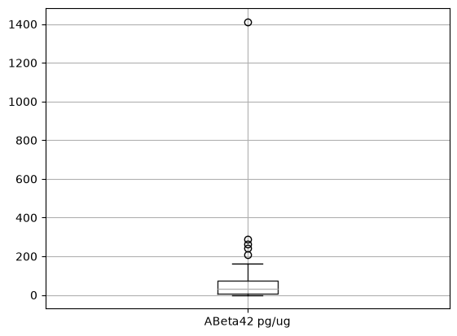

```python
# First check of outlier analysis!
df = pd.read_csv("Metadata and Protein Data for Module 1.csv")
col = "ABeta42 pg/ug"       # protein concentration column to check
id_col = "Donor ID"        # column that identifies each patient
df = df.dropna(subset=[col])

# IQR: flag anything beyond 1.5 * IQR from the quartiles
q1, q3 = df[col].quantile([0.25, 0.75])
iqr = q3 - q1
low, high = q1 - 1.5 * iqr, q3 + 1.5 * iqr
df["outlier"] = (df[col] < low) | (df[col] > high)

# z-score
df["z"] = (df[col] - df[col].mean()) / df[col].std()

print(f"Normal range: {low:.2f} to {high:.2f}")
print(df.loc[df["outlier"], [id_col, col, "z"]])

df.boxplot(column=col)
plt.show()
```

*Step 3: The data was compiled into graphs with the desired traits*

And

*Step 4: The data was analysed for the possibility of significance*

Python is then used to calculate the duration of the disease

```python
# Calculate disease duration
# Disease duration = age at death - age of symptom onset

disease_duration = []

for patient in Patient.all_patients:
    if patient.age_onset is not None:
        duration = patient.age_at_death - patient.age_onset
        disease_duration.append(duration)

# Print disease duration information
print("\nDisease duration:")
print(f"Number of patients with disease duration data = {len(disease_duration)}")
if disease_duration:
    print(f"Mean disease duration = {statistics.mean(disease_duration):.2f} years")
    print(f"Standard deviation of disease duration = {statistics.stdev(disease_duration):.2f} years")
else:
    print("Mean disease duration = N/A")
    print("Standard deviation of disease duration = N/A")
```

```
Disease duration:
Number of patients with disease duration data = 37
Mean disease duration = 6.59 years
Standard deviation of disease duration = 4.26 years
```

```
Disease duration by education level:
High School: mean = 5.00, SD = 6.24
Trade School: mean = 2.86, SD = 3.18
Bachelors: mean = 4.29, SD = 4.35
Graduate: mean = 4.46, SD = 3.67
Professional: mean = 2.67, SD = 0.58
```

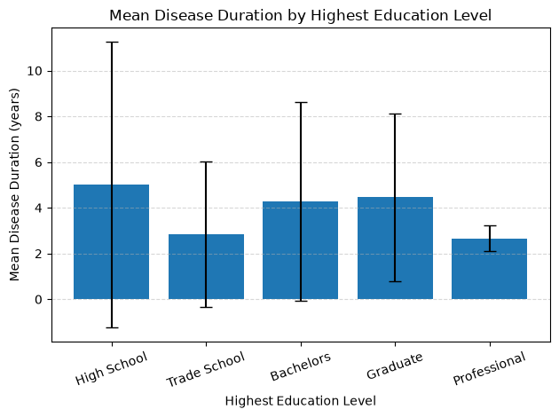

```python
# Now, we will create graphs.
# First up, is the bar graph:


# Bar graph
# Mean disease duration +/- standard deviation for each education level
high_school_duration = []
trade_school_duration = []
bachelors_duration = []
graduate_duration = []
professional_duration = []

for patient in Patient.all_patients:
    if patient.age_dementia_diagnosis is not None:
        duration = patient.age_at_death - patient.age_dementia_diagnosis

        if patient.highest_education == "High School":
            high_school_duration.append(duration)
        elif patient.highest_education == "Trade School/ Tech School":
            trade_school_duration.append(duration)
        elif patient.highest_education == "Bachelors":
            bachelors_duration.append(duration)
        elif patient.highest_education == "Graduate (PhD/Masters)":
            graduate_duration.append(duration)
        elif patient.highest_education == "Professional":
            professional_duration.append(duration)


def safe_mean(values):
    return statistics.mean(values) if values else 0.0


def safe_stdev(values):
    return statistics.stdev(values) if len(values) > 1 else 0.0

# Calculate means
mean_high_school = safe_mean(high_school_duration)
mean_trade_school = safe_mean(trade_school_duration)
mean_bachelors = safe_mean(bachelors_duration)
mean_graduate = safe_mean(graduate_duration)
mean_professional = safe_mean(professional_duration)

# Calculate standard deviations
stdev_high_school = safe_stdev(high_school_duration)
stdev_trade_school = safe_stdev(trade_school_duration)
stdev_bachelors = safe_stdev(bachelors_duration)
stdev_graduate = safe_stdev(graduate_duration)
stdev_professional = safe_stdev(professional_duration)

# Print statistics
print("\nDisease duration by education level:")
print(f"High School: mean = {mean_high_school:.2f}, SD = {stdev_high_school:.2f}")
print(f"Trade School: mean = {mean_trade_school:.2f}, SD = {stdev_trade_school:.2f}")
print(f"Bachelors: mean = {mean_bachelors:.2f}, SD = {stdev_bachelors:.2f}")
print(f"Graduate: mean = {mean_graduate:.2f}, SD = {stdev_graduate:.2f}")
print(f"Professional: mean = {mean_professional:.2f}, SD = {stdev_professional:.2f}")

# Make bar graph

education_labels = [
    "High School",
    "Trade School",
    "Bachelors",
    "Graduate",
    "Professional",
]

education_means = [
    mean_high_school,
    mean_trade_school,
    mean_bachelors,
    mean_graduate,
    mean_professional,
]

education_stdev = [
    stdev_high_school,
    stdev_trade_school,
    stdev_bachelors,
    stdev_graduate,
    stdev_professional,
]

# Labels to make the bar graph more readable


plt.bar(
    education_labels,
    education_means,
    yerr=education_stdev,
    capsize=5
)

plt.title(
    "Mean Disease Duration by Highest Education Level"
)

plt.xlabel(
    "Highest Education Level"
)

plt.ylabel(
    "Mean Disease Duration (years)"
)

plt.xticks(rotation=20)

plt.grid(
    axis="y",
    linestyle="--",
    alpha=0.5
)

plt.tight_layout()
plt.show()
```

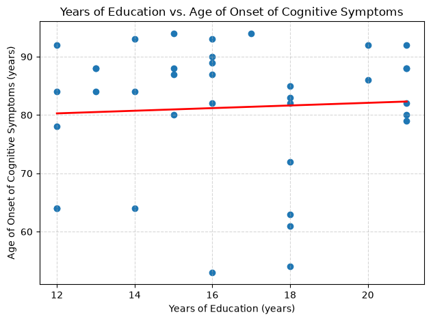

```
R-squared value: 0.00
P-value = 0.726
```

```python
# Scatter plot
# Years of education vs. age of onset of cognitive symptoms

years_education = []
age_onset = []

for patient in Patient.all_patients:
    if patient.age_onset is not None and patient.years_education is not None:
        years_education.append(patient.years_education)
        age_onset.append(patient.age_onset)


model = LinearRegression()
model.fit(np.array(years_education).reshape(-1, 1), np.array(age_onset).reshape(-1, 1))

X = np.linspace(
    min(years_education),
    max(years_education),
    100
).reshape(-1, 1)

# Make scatter plot
plt.scatter(
    years_education,
    age_onset
)

plt.title(
    "Years of Education vs. Age of Onset of Cognitive Symptoms"
)

plt.xlabel(
    "Years of Education (years)"
)

plt.ylabel(
    "Age of Onset of Cognitive Symptoms (years)"
)

plt.grid(
    linestyle="--",
    alpha=0.5
)
# Add regression line
plt.plot(X, model.predict(X).ravel(), color="red", linewidth=2)

plt.tight_layout()
plt.show()

# make r squared value
r_squared = model.score(np.array(years_education).reshape(-1, 1), np.array(age_onset).reshape(-1, 1))
print(f"R-squared value: {r_squared:.2f}")

# Calculate p-value
slope, intercept, r_value, p_value, standard_error = stats.linregress(
    years_education,
    age_onset
)

print(f"P-value = {p_value:.3f}")
```

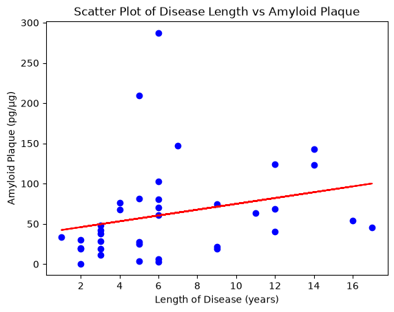

```
The R squared value is: 0.06572229463702106
The p value is: [0.12562087]
```

```python
# This scatterplot relates length of time from disease onset to death to the amount of amyloid plaque

# These are empty lists to store the data
disease_length = []
amyloid_plaque_levels = []

for p in Patient.all_patients:
    if p.age_onset is not None and p.age_at_death is not None:
        disease_length.append(p.age_at_death - p.age_onset)
        amyloid_plaque_levels.append(p.abeta42)

x_values = np.array(disease_length, dtype=float)
y_values = np.array(amyloid_plaque_levels, dtype=float)

# Uses patients with valid values for both variables
valid_data = np.isfinite(x_values) & np.isfinite(y_values)
x = x_values[valid_data].reshape(-1, 1)
y = y_values[valid_data].reshape(-1, 1)

# Make a linear regression
model = LinearRegression()
model.fit(x, y)
r2 = model.score(x, y)

# Plot and show
plt.scatter(x, y, color='blue')
plt.plot(x, model.predict(x), color='red')
plt.xlabel('Length of Disease (years)')
plt.ylabel('Amyloid Plaque (pg/µg)')
plt.title('Scatter Plot of Disease Length vs Amyloid Plaque')
plt.show()

# R and p values
print("The R squared value is:", r2)
r, p_val = stats.pearsonr(x, y)
print('The p value is:', p_val)
```

## Conclusion:

In the bar graph, the means and standard deviations had very clear overlap, meaning there was no statistical significance.

When analyzing education level and age of onset, the calculated R2 = 0.0035 and the p-value is 0.726, well above the 0.05 significance threshold. We can then determine that the correlation is not statistically significant.

There appears to be a slight correlation between disease duration and the levels of Amyloid plaque, however, the calculated p-value is 0.125, which is above the 0.05 threshold, determining that this correlation is also not statistically significant.

*Due to these p values and R squared relations of our data, we were not able to conclude statistical significance from any of our data. The bar graph, and both scatterplots have no clear correlation.*

## Verify and validate your analysis:

### Does the data make sense intuitively?

- Our data showed a slight correlation between levels of Amyloid Plaque and disease duration, which logically makes sense, though our p-value did not demonstrate significance
- Based on our data analysis, we did not find a statistically significant correlation between years of formal education and age of onset of Alzheimer’s
  - This challenges some findings discovered in our initial research, where some sources (specifically a CDC fact sheet) generalized that higher levels of education could delay onset or reduce likelihood of developing the disease

### Are data conclusions reflected in the field of understanding?

- According to a study published in Alzheimer's & Dementia Journal: “Amyloid and tau accumulation in Alzheimer’s disease is known to be dynamic, with expected rates of accumulation varying depending on disease stage”
- Education has been found to have an impact on Alzheimer’s in some studies, but its impacts might go beyond raw years of schooling
  - Some scientists have suggested that cognitive engagement can be stored or “banked” in early years of life, which can help protect against Alzheimer’s (cognitive reserve)
  - Type of learning and mental engagement throughout life could possibly matter more than degree accumulation

Sources: Young, Alexandra L et al. “Disease timeline modelling of amyloid and tau PET reveals dynamic timescales of amyloid and tau accumulation in Alzheimer’s disease.” Alzheimer's & Dementia vol. 21,Suppl 8 e110838. 23 Dec. 2025, doi:10.1002/alz70862_110838

https://lcc.umn.edu/news-events/research-snapshots/how-does-education-affect-alzheimers-and-dementia-risk-its-about

## Conclusions and Ethical Implications

Through this project, we concluded that:

- Accumulation of Amyloid plaque might not have a direct impact on disease length based on our data and statistical analysis, with one possible explanation being the variable or nonuniform rate of plaque accumulation
- Based on our data set, years of formal education might not have a huge impact on age of onset of cognitive symptoms, while other forms of education and neurological engagement later in life might contribute more to “cognitive reserve”

Ethical Considerations: Despite our project's analysis being largely inconclusive, studies of this type could have a massive impact on the direction of research, lifestyle recommendations and health guidance, and the overall public understanding of the disease

- Underscores the importance of true and accurate data reporting
- Since real patient data was used, it's important that researchers respect the dignity, privacy, and sacrifice many people made to contribute to the greater good

## Limitations and Future Work

### Limiations

One limitation was simply the scope of the data provided in our dataset, as we are unable to determine factors that could impact "cognitive reseerve" such as profession, sleep habits, and other lifestyle data. Additionally, an increased sample size could help improve the accuracy of our statistical analysis.

### If we had more time:

- We could analyze additional datasets to provide more insight into habits, professions, or genetic factors
- Explore questions with additional categories including protein levels, brain pH, disease duration, head injury, etc.

## AI Usage Statement:

AI Utulized:

- Chat GPT 5.6 Luna for general syntax assistance and understanding
- Internal VS Code bot for debugging and indentation assistance
- Used Claude Sonnet 5.5 for debugging
- Used Claude Sonnet 5.5 to explain the python tools and concepts for outlier analysis

## GitHub Repository Link:

GitHub Repository Link: https://github.com/LayR451/BME2315_Module1

This is the link to our Github: https://github.com/LayR451/BME2315_Module1

- Within the Github, all revelant final files are in the FINAL PROJECT Folder.

This is the link to our Github: https://github.com/LayR451/BME2315_Module1

- Within the Github, all revelant final files are in the FINAL PROJECT Folder.

Other Links: Presentation slideshow link (delivered in class): https://myuva-my.sharepoint.com/:p:/g/personal/kjf4ea_virginia_edu/IQClClvP5OdNRpbPEbSMFDfTAcCZmI9OxmtOl9ocyYDPoyM?e=0VG1Vs